# Risk Factor Analysis

## Outcome Variable

**Outcome Variable:** ever_wasted

## Predictor Variables

**Intervention Variable:** parity

**Adjustment Set:**

- arm
- W_mage
- meducyrs
- feducyrs
- hhwealth_quart
- W_mhtcm
- W_mwtkg
- W_mbmi
- vagbrth
- W_nrooms
- impsan
- delta_W_mage
- delta_meducyrs
- delta_feducyrs
- delta_hhwealth_quart
- delta_W_mhtcm
- delta_W_mwtkg
- delta_W_mbmi
- delta_vagbrth
- delta_W_nrooms
- delta_impsan

## Stratifying Variables

The analysis was stratified on these variable(s):

- agecat
- studyid
- country

## Data Summary

| agecat | studyid | country | parity | ever_wasted | n_cell | n |
| --- | --- | --- | --- | --- | --- | --- |
| 0-24 months | ki1000304b-SAS-CompFeed | INDIA | 1 | 0 | 273 | 1513 |
| 0-24 months | ki1000304b-SAS-CompFeed | INDIA | 1 | 1 | 175 | 1513 |
| 0-24 months | ki1000304b-SAS-CompFeed | INDIA | 2 | 0 | 219 | 1513 |
| 0-24 months | ki1000304b-SAS-CompFeed | INDIA | 2 | 1 | 135 | 1513 |
| 0-24 months | ki1000304b-SAS-CompFeed | INDIA | 3+ | 0 | 393 | 1513 |
| 0-24 months | ki1000304b-SAS-CompFeed | INDIA | 3+ | 1 | 318 | 1513 |
| 0-24 months | ki1000304b-SAS-FoodSuppl | INDIA | 1 | 0 | 12 | 418 |
| 0-24 months | ki1000304b-SAS-FoodSuppl | INDIA | 1 | 1 | 9 | 418 |
| 0-24 months | ki1000304b-SAS-FoodSuppl | INDIA | 2 | 0 | 51 | 418 |
| 0-24 months | ki1000304b-SAS-FoodSuppl | INDIA | 2 | 1 | 26 | 418 |
| 0-24 months | ki1000304b-SAS-FoodSuppl | INDIA | 3+ | 0 | 158 | 418 |
| 0-24 months | ki1000304b-SAS-FoodSuppl | INDIA | 3+ | 1 | 162 | 418 |
| 0-24 months | ki1017093b-PROVIDE | BANGLADESH | 1 | 0 | 163 | 700 |
| 0-24 months | ki1017093b-PROVIDE | BANGLADESH | 1 | 1 | 108 | 700 |
| 0-24 months | ki1017093b-PROVIDE | BANGLADESH | 2 | 0 | 170 | 700 |
| 0-24 months | ki1017093b-PROVIDE | BANGLADESH | 2 | 1 | 74 | 700 |
| 0-24 months | ki1017093b-PROVIDE | BANGLADESH | 3+ | 0 | 121 | 700 |
| 0-24 months | ki1017093b-PROVIDE | BANGLADESH | 3+ | 1 | 64 | 700 |
| 0-24 months | ki1066203-TanzaniaChild2 | TANZANIA, UNITED REPUBLIC OF | 1 | 0 | 624 | 2357 |
| 0-24 months | ki1066203-TanzaniaChild2 | TANZANIA, UNITED REPUBLIC OF | 1 | 1 | 197 | 2357 |
| 0-24 months | ki1066203-TanzaniaChild2 | TANZANIA, UNITED REPUBLIC OF | 2 | 0 | 583 | 2357 |
| 0-24 months | ki1066203-TanzaniaChild2 | TANZANIA, UNITED REPUBLIC OF | 2 | 1 | 188 | 2357 |
| 0-24 months | ki1066203-TanzaniaChild2 | TANZANIA, UNITED REPUBLIC OF | 3+ | 0 | 592 | 2357 |
| 0-24 months | ki1066203-TanzaniaChild2 | TANZANIA, UNITED REPUBLIC OF | 3+ | 1 | 173 | 2357 |
| 0-24 months | ki1101329-Keneba | GAMBIA | 1 | 0 | 131 | 1990 |
| 0-24 months | ki1101329-Keneba | GAMBIA | 1 | 1 | 109 | 1990 |
| 0-24 months | ki1101329-Keneba | GAMBIA | 2 | 0 | 118 | 1990 |
| 0-24 months | ki1101329-Keneba | GAMBIA | 2 | 1 | 96 | 1990 |
| 0-24 months | ki1101329-Keneba | GAMBIA | 3+ | 0 | 771 | 1990 |
| 0-24 months | ki1101329-Keneba | GAMBIA | 3+ | 1 | 765 | 1990 |

[output cut: 168 more lines]

The following strata were considered:

- agecat: 0-24 months, studyid: ki1000304b-SAS-CompFeed, country: INDIA
- agecat: 0-24 months, studyid: ki1000304b-SAS-FoodSuppl, country: INDIA
- agecat: 0-24 months, studyid: ki1017093b-PROVIDE, country: BANGLADESH
- agecat: 0-24 months, studyid: ki1066203-TanzaniaChild2, country: TANZANIA, UNITED REPUBLIC OF
- agecat: 0-24 months, studyid: ki1101329-Keneba, country: GAMBIA
- agecat: 0-24 months, studyid: ki1113344-GMS-Nepal, country: NEPAL
- agecat: 0-24 months, studyid: ki1126311-ZVITAMBO, country: ZIMBABWE
- agecat: 0-24 months, studyid: ki1135781-COHORTS, country: GUATEMALA
- agecat: 0-24 months, studyid: ki1135781-COHORTS, country: INDIA
- agecat: 0-24 months, studyid: ki1135781-COHORTS, country: PHILIPPINES
- agecat: 0-24 months, studyid: kiGH5241-JiVitA-3, country: BANGLADESH
- agecat: 0-6 months, studyid: ki1000304b-SAS-CompFeed, country: INDIA
- agecat: 0-6 months, studyid: ki1000304b-SAS-FoodSuppl, country: INDIA
- agecat: 0-6 months, studyid: ki1017093b-PROVIDE, country: BANGLADESH
- agecat: 0-6 months, studyid: ki1066203-TanzaniaChild2, country: TANZANIA, UNITED REPUBLIC OF
- agecat: 0-6 months, studyid: ki1101329-Keneba, country: GAMBIA
- agecat: 0-6 months, studyid: ki1113344-GMS-Nepal, country: NEPAL
- agecat: 0-6 months, studyid: ki1126311-ZVITAMBO, country: ZIMBABWE
- agecat: 0-6 months, studyid: ki1135781-COHORTS, country: GUATEMALA
- agecat: 0-6 months, studyid: ki1135781-COHORTS, country: INDIA
- agecat: 0-6 months, studyid: ki1135781-COHORTS, country: PHILIPPINES
- agecat: 0-6 months, studyid: kiGH5241-JiVitA-3, country: BANGLADESH
- agecat: 6-24 months, studyid: ki1000304b-SAS-CompFeed, country: INDIA
- agecat: 6-24 months, studyid: ki1000304b-SAS-FoodSuppl, country: INDIA
- agecat: 6-24 months, studyid: ki1017093b-PROVIDE, country: BANGLADESH
- agecat: 6-24 months, studyid: ki1066203-TanzaniaChild2, country: TANZANIA, UNITED REPUBLIC OF
- agecat: 6-24 months, studyid: ki1101329-Keneba, country: GAMBIA
- agecat: 6-24 months, studyid: ki1113344-GMS-Nepal, country: NEPAL
- agecat: 6-24 months, studyid: ki1126311-ZVITAMBO, country: ZIMBABWE
- agecat: 6-24 months, studyid: ki1135781-COHORTS, country: GUATEMALA
- agecat: 6-24 months, studyid: ki1135781-COHORTS, country: INDIA
- agecat: 6-24 months, studyid: ki1135781-COHORTS, country: PHILIPPINES
- agecat: 6-24 months, studyid: kiGH5241-JiVitA-3, country: BANGLADESH

### Dropped Strata

Some strata were dropped due to rare outcomes:

- agecat: 6-24 months, studyid: ki1000304b-SAS-FoodSuppl, country: INDIA

## Methods Detail

We’re interested in the causal parameters $E[Y_a]$ for all values of $a \in \mathcal{A}$. These parameters represent the mean outcome if, possibly contrary to fact, we intervened to set all units to have $A=a$. Under the randomization and positivity assumptions, these are identified by the statistical parameters $\psi_a=E_W[E_{Y|A,W}(Y|A=a,W)]$. In addition, we’re interested in the mean of $Y$, $E[Y]$ under no intervention (the observed mean). We will estimate these parameters by using SuperLearner to fit the relevant likelihood factors – $E_{Y|A,W}(Y|A=a,W)$ and $p(A=a|W)$, and then updating our likelihood fit using a joint TMLE.

For unadjusted analyses ($W=\{\}$), initial likelihoods were estimated using Lrnr_glm to estimate the simple $E(Y|A)$ and Lrnr_mean to estimate $p(A)$. For adjusted analyses, a small library containing Lrnr_glmnet, Lrnr_xgboost, and Lrnr_mean was used.

Having estimated these parameters, we will then use the delta method to estimate relative risks and attributable risks relative to a prespecified baseline level of $A$.

# Results Detail

## Results Plots

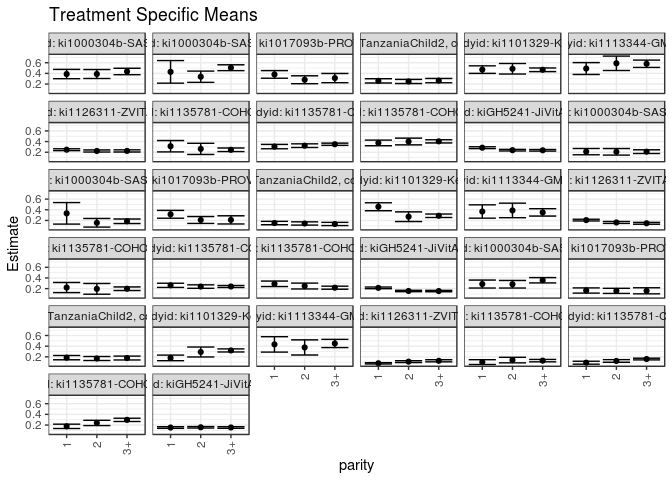

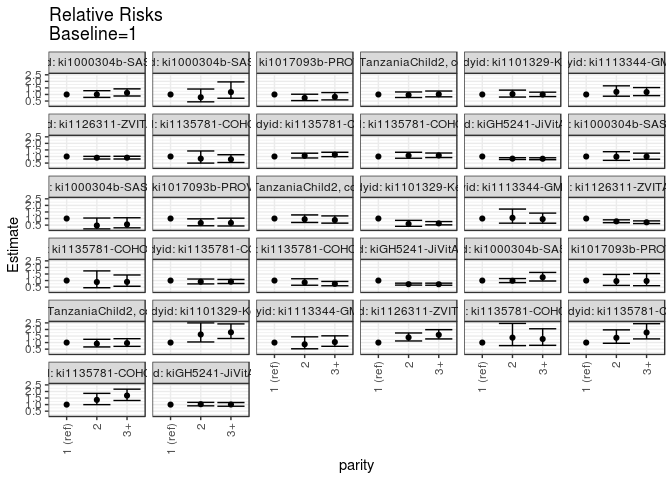

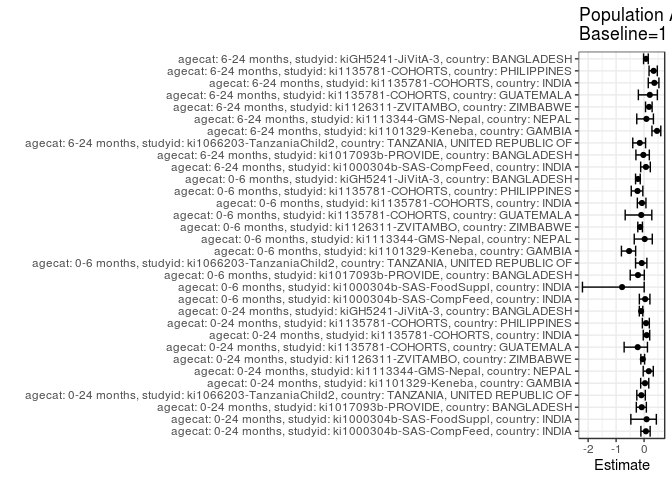

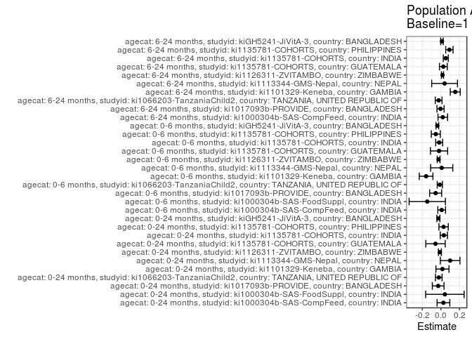

## Results Table

### Parameter: TSM

| agecat | studyid | country | intervention_level | baseline_level | estimate | ci_lower | ci_upper |
| --- | --- | --- | --- | --- | --- | --- | --- |
| 0-24 months | ki1000304b-SAS-CompFeed | INDIA | 1 | NA | 0.3878338 | 0.3008153 | 0.4748523 |
| 0-24 months | ki1000304b-SAS-CompFeed | INDIA | 2 | NA | 0.3882339 | 0.3041969 | 0.4722710 |
| 0-24 months | ki1000304b-SAS-CompFeed | INDIA | 3+ | NA | 0.4357586 | 0.3755557 | 0.4959616 |
| 0-24 months | ki1000304b-SAS-FoodSuppl | INDIA | 1 | NA | 0.4285714 | 0.2166616 | 0.6404813 |
| 0-24 months | ki1000304b-SAS-FoodSuppl | INDIA | 2 | NA | 0.3376623 | 0.2319066 | 0.4434181 |
| 0-24 months | ki1000304b-SAS-FoodSuppl | INDIA | 3+ | NA | 0.5062500 | 0.4514060 | 0.5610940 |
| 0-24 months | ki1017093b-PROVIDE | BANGLADESH | 1 | NA | 0.3807698 | 0.3089972 | 0.4525423 |
| 0-24 months | ki1017093b-PROVIDE | BANGLADESH | 2 | NA | 0.2807457 | 0.2065708 | 0.3549206 |
| 0-24 months | ki1017093b-PROVIDE | BANGLADESH | 3+ | NA | 0.3121046 | 0.2254307 | 0.3987786 |
| 0-24 months | ki1066203-TanzaniaChild2 | TANZANIA, UNITED REPUBLIC OF | 1 | NA | 0.2597867 | 0.2198353 | 0.2997380 |
| 0-24 months | ki1066203-TanzaniaChild2 | TANZANIA, UNITED REPUBLIC OF | 2 | NA | 0.2484324 | 0.2096846 | 0.2871802 |
| 0-24 months | ki1066203-TanzaniaChild2 | TANZANIA, UNITED REPUBLIC OF | 3+ | NA | 0.2643440 | 0.2241024 | 0.3045856 |
| 0-24 months | ki1101329-Keneba | GAMBIA | 1 | NA | 0.4708205 | 0.3998647 | 0.5417764 |
| 0-24 months | ki1101329-Keneba | GAMBIA | 2 | NA | 0.4866077 | 0.3878141 | 0.5854013 |
| 0-24 months | ki1101329-Keneba | GAMBIA | 3+ | NA | 0.4678902 | 0.4337265 | 0.5020540 |
| 0-24 months | ki1113344-GMS-Nepal | NEPAL | 1 | NA | 0.4912998 | 0.3798913 | 0.6027084 |
| 0-24 months | ki1113344-GMS-Nepal | NEPAL | 2 | NA | 0.5895273 | 0.4542471 | 0.7248075 |
| 0-24 months | ki1113344-GMS-Nepal | NEPAL | 3+ | NA | 0.5807649 | 0.5116953 | 0.6498345 |
| 0-24 months | ki1126311-ZVITAMBO | ZIMBABWE | 1 | NA | 0.2475840 | 0.2301603 | 0.2650077 |
| 0-24 months | ki1126311-ZVITAMBO | ZIMBABWE | 2 | NA | 0.2236088 | 0.2040185 | 0.2431991 |
| 0-24 months | ki1126311-ZVITAMBO | ZIMBABWE | 3+ | NA | 0.2249415 | 0.2046310 | 0.2452520 |
| 0-24 months | ki1135781-COHORTS | GUATEMALA | 1 | NA | 0.3130606 | 0.2062526 | 0.4198686 |
| 0-24 months | ki1135781-COHORTS | GUATEMALA | 2 | NA | 0.2633146 | 0.1584617 | 0.3681675 |
| 0-24 months | ki1135781-COHORTS | GUATEMALA | 3+ | NA | 0.2460475 | 0.2125590 | 0.2795361 |
| 0-24 months | ki1135781-COHORTS | INDIA | 1 | NA | 0.3064174 | 0.2656660 | 0.3471689 |
| 0-24 months | ki1135781-COHORTS | INDIA | 2 | NA | 0.3234576 | 0.2887561 | 0.3581590 |
| 0-24 months | ki1135781-COHORTS | INDIA | 3+ | NA | 0.3503698 | 0.3296700 | 0.3710696 |
| 0-24 months | ki1135781-COHORTS | PHILIPPINES | 1 | NA | 0.3748867 | 0.3223130 | 0.4274604 |
| 0-24 months | ki1135781-COHORTS | PHILIPPINES | 2 | NA | 0.4015503 | 0.3383455 | 0.4647552 |
| 0-24 months | ki1135781-COHORTS | PHILIPPINES | 3+ | NA | 0.4044755 | 0.3746492 | 0.4343019 |

[output cut: 66 more lines]

### Parameter: E(Y)

| agecat | studyid | country | intervention_level | baseline_level | estimate | ci_lower | ci_upper |
| --- | --- | --- | --- | --- | --- | --- | --- |
| 0-24 months | ki1000304b-SAS-CompFeed | INDIA | NA | NA | 0.4150694 | 0.3581204 | 0.4720184 |
| 0-24 months | ki1000304b-SAS-FoodSuppl | INDIA | NA | NA | 0.4712919 | 0.4233811 | 0.5192026 |
| 0-24 months | ki1017093b-PROVIDE | BANGLADESH | NA | NA | 0.3514286 | 0.3160364 | 0.3868207 |
| 0-24 months | ki1066203-TanzaniaChild2 | TANZANIA, UNITED REPUBLIC OF | NA | NA | 0.2367416 | 0.2195770 | 0.2539062 |
| 0-24 months | ki1101329-Keneba | GAMBIA | NA | NA | 0.4874372 | 0.4654705 | 0.5094038 |
| 0-24 months | ki1113344-GMS-Nepal | NEPAL | NA | NA | 0.5903790 | 0.5535526 | 0.6272054 |
| 0-24 months | ki1126311-ZVITAMBO | ZIMBABWE | NA | NA | 0.2367157 | 0.2296604 | 0.2437709 |
| 0-24 months | ki1135781-COHORTS | GUATEMALA | NA | NA | 0.2550336 | 0.2316956 | 0.2783715 |
| 0-24 months | ki1135781-COHORTS | INDIA | NA | NA | 0.3378028 | 0.3241691 | 0.3514364 |
| 0-24 months | ki1135781-COHORTS | PHILIPPINES | NA | NA | 0.4036125 | 0.3861835 | 0.4210415 |
| 0-24 months | kiGH5241-JiVitA-3 | BANGLADESH | NA | NA | 0.2580131 | 0.2515484 | 0.2644777 |
| 0-6 months | ki1000304b-SAS-CompFeed | INDIA | NA | NA | 0.2199336 | 0.1753445 | 0.2645227 |
| 0-6 months | ki1000304b-SAS-FoodSuppl | INDIA | NA | NA | 0.1866029 | 0.1492099 | 0.2239959 |
| 0-6 months | ki1017093b-PROVIDE | BANGLADESH | NA | NA | 0.2585714 | 0.2261125 | 0.2910304 |
| 0-6 months | ki1066203-TanzaniaChild2 | TANZANIA, UNITED REPUBLIC OF | NA | NA | 0.1395842 | 0.1255905 | 0.1535779 |
| 0-6 months | ki1101329-Keneba | GAMBIA | NA | NA | 0.2976769 | 0.2768415 | 0.3185124 |
| 0-6 months | ki1113344-GMS-Nepal | NEPAL | NA | NA | 0.3760933 | 0.3398180 | 0.4123685 |
| 0-6 months | ki1126311-ZVITAMBO | ZIMBABWE | NA | NA | 0.1811291 | 0.1747154 | 0.1875428 |
| 0-6 months | ki1135781-COHORTS | GUATEMALA | NA | NA | 0.2003763 | 0.1763021 | 0.2244505 |
| 0-6 months | ki1135781-COHORTS | INDIA | NA | NA | 0.2434743 | 0.2308547 | 0.2560940 |
| 0-6 months | ki1135781-COHORTS | PHILIPPINES | NA | NA | 0.2355453 | 0.2204685 | 0.2506222 |
| 0-6 months | kiGH5241-JiVitA-3 | BANGLADESH | NA | NA | 0.1761793 | 0.1705546 | 0.1818041 |
| 6-24 months | ki1000304b-SAS-CompFeed | INDIA | NA | NA | 0.3059755 | 0.2638053 | 0.3481458 |
| 6-24 months | ki1017093b-PROVIDE | BANGLADESH | NA | NA | 0.1609756 | 0.1319065 | 0.1900447 |
| 6-24 months | ki1066203-TanzaniaChild2 | TANZANIA, UNITED REPUBLIC OF | NA | NA | 0.1600403 | 0.1439152 | 0.1761654 |
| 6-24 months | ki1101329-Keneba | GAMBIA | NA | NA | 0.3336798 | 0.3126050 | 0.3547547 |
| 6-24 months | ki1113344-GMS-Nepal | NEPAL | NA | NA | 0.4728814 | 0.4325613 | 0.5132014 |
| 6-24 months | ki1126311-ZVITAMBO | ZIMBABWE | NA | NA | 0.0958942 | 0.0903444 | 0.1014441 |
| 6-24 months | ki1135781-COHORTS | GUATEMALA | NA | NA | 0.1269580 | 0.1082147 | 0.1457012 |
| 6-24 months | ki1135781-COHORTS | INDIA | NA | NA | 0.1419682 | 0.1315821 | 0.1523542 |
| 6-24 months | ki1135781-COHORTS | PHILIPPINES | NA | NA | 0.2666429 | 0.2502871 | 0.2829988 |
| 6-24 months | kiGH5241-JiVitA-3 | BANGLADESH | NA | NA | 0.1640074 | 0.1578946 | 0.1701202 |

### Parameter: RR

| agecat | studyid | country | intervention_level | baseline_level | estimate | ci_lower | ci_upper |
| --- | --- | --- | --- | --- | --- | --- | --- |
| 0-24 months | ki1000304b-SAS-CompFeed | INDIA | 1 | 1 | 1.0000000 | 1.0000000 | 1.0000000 |
| 0-24 months | ki1000304b-SAS-CompFeed | INDIA | 2 | 1 | 1.0010318 | 0.7781003 | 1.2878347 |
| 0-24 months | ki1000304b-SAS-CompFeed | INDIA | 3+ | 1 | 1.1235705 | 0.8841013 | 1.4279028 |
| 0-24 months | ki1000304b-SAS-FoodSuppl | INDIA | 1 | 1 | 1.0000000 | 1.0000000 | 1.0000000 |
| 0-24 months | ki1000304b-SAS-FoodSuppl | INDIA | 2 | 1 | 0.7878788 | 0.4387984 | 1.4146657 |
| 0-24 months | ki1000304b-SAS-FoodSuppl | INDIA | 3+ | 1 | 1.1812500 | 0.7120467 | 1.9596350 |
| 0-24 months | ki1017093b-PROVIDE | BANGLADESH | 1 | 1 | 1.0000000 | 1.0000000 | 1.0000000 |
| 0-24 months | ki1017093b-PROVIDE | BANGLADESH | 2 | 1 | 0.7373109 | 0.5333410 | 1.0192866 |
| 0-24 months | ki1017093b-PROVIDE | BANGLADESH | 3+ | 1 | 0.8196676 | 0.5865482 | 1.1454387 |
| 0-24 months | ki1066203-TanzaniaChild2 | TANZANIA, UNITED REPUBLIC OF | 1 | 1 | 1.0000000 | 1.0000000 | 1.0000000 |
| 0-24 months | ki1066203-TanzaniaChild2 | TANZANIA, UNITED REPUBLIC OF | 2 | 1 | 0.9562939 | 0.7685247 | 1.1899396 |
| 0-24 months | ki1066203-TanzaniaChild2 | TANZANIA, UNITED REPUBLIC OF | 3+ | 1 | 1.0175426 | 0.8193881 | 1.2636173 |
| 0-24 months | ki1101329-Keneba | GAMBIA | 1 | 1 | 1.0000000 | 1.0000000 | 1.0000000 |
| 0-24 months | ki1101329-Keneba | GAMBIA | 2 | 1 | 1.0335312 | 0.8026587 | 1.3308107 |
| 0-24 months | ki1101329-Keneba | GAMBIA | 3+ | 1 | 0.9937762 | 0.8405475 | 1.1749379 |
| 0-24 months | ki1113344-GMS-Nepal | NEPAL | 1 | 1 | 1.0000000 | 1.0000000 | 1.0000000 |
| 0-24 months | ki1113344-GMS-Nepal | NEPAL | 2 | 1 | 1.1999338 | 0.8689124 | 1.6570612 |
| 0-24 months | ki1113344-GMS-Nepal | NEPAL | 3+ | 1 | 1.1820987 | 0.9148148 | 1.5274756 |
| 0-24 months | ki1126311-ZVITAMBO | ZIMBABWE | 1 | 1 | 1.0000000 | 1.0000000 | 1.0000000 |
| 0-24 months | ki1126311-ZVITAMBO | ZIMBABWE | 2 | 1 | 0.9031634 | 0.8072106 | 1.0105221 |
| 0-24 months | ki1126311-ZVITAMBO | ZIMBABWE | 3+ | 1 | 0.9085462 | 0.8102920 | 1.0187145 |
| 0-24 months | ki1135781-COHORTS | GUATEMALA | 1 | 1 | 1.0000000 | 1.0000000 | 1.0000000 |
| 0-24 months | ki1135781-COHORTS | GUATEMALA | 2 | 1 | 0.8410978 | 0.4976068 | 1.4216957 |
| 0-24 months | ki1135781-COHORTS | GUATEMALA | 3+ | 1 | 0.7859422 | 0.5441937 | 1.1350831 |
| 0-24 months | ki1135781-COHORTS | INDIA | 1 | 1 | 1.0000000 | 1.0000000 | 1.0000000 |
| 0-24 months | ki1135781-COHORTS | INDIA | 2 | 1 | 1.0556108 | 0.8899403 | 1.2521224 |
| 0-24 months | ki1135781-COHORTS | INDIA | 3+ | 1 | 1.1434396 | 0.9885941 | 1.3225388 |
| 0-24 months | ki1135781-COHORTS | PHILIPPINES | 1 | 1 | 1.0000000 | 1.0000000 | 1.0000000 |
| 0-24 months | ki1135781-COHORTS | PHILIPPINES | 2 | 1 | 1.0711245 | 0.8675112 | 1.3225278 |
| 0-24 months | ki1135781-COHORTS | PHILIPPINES | 3+ | 1 | 1.0789274 | 0.9208208 | 1.2641813 |

[output cut: 66 more lines]

### Parameter: PAR

| agecat | studyid | country | intervention_level | baseline_level | estimate | ci_lower | ci_upper |
| --- | --- | --- | --- | --- | --- | --- | --- |
| 0-24 months | ki1000304b-SAS-CompFeed | INDIA | 1 | NA | 0.0272356 | -0.0410007 | 0.0954719 |
| 0-24 months | ki1000304b-SAS-FoodSuppl | INDIA | 1 | NA | 0.0427204 | -0.1638931 | 0.2493340 |
| 0-24 months | ki1017093b-PROVIDE | BANGLADESH | 1 | NA | -0.0293412 | -0.0920682 | 0.0333858 |
| 0-24 months | ki1066203-TanzaniaChild2 | TANZANIA, UNITED REPUBLIC OF | 1 | NA | -0.0230450 | -0.0588493 | 0.0127592 |
| 0-24 months | ki1101329-Keneba | GAMBIA | 1 | NA | 0.0166167 | -0.0537218 | 0.0869551 |
| 0-24 months | ki1113344-GMS-Nepal | NEPAL | 1 | NA | 0.0990792 | -0.0063749 | 0.2045332 |
| 0-24 months | ki1126311-ZVITAMBO | ZIMBABWE | 1 | NA | -0.0108683 | -0.0267416 | 0.0050049 |
| 0-24 months | ki1135781-COHORTS | GUATEMALA | 1 | NA | -0.0580271 | -0.1622560 | 0.0462019 |
| 0-24 months | ki1135781-COHORTS | INDIA | 1 | NA | 0.0313853 | -0.0074932 | 0.0702638 |
| 0-24 months | ki1135781-COHORTS | PHILIPPINES | 1 | NA | 0.0287258 | -0.0213798 | 0.0788314 |
| 0-24 months | kiGH5241-JiVitA-3 | BANGLADESH | 1 | NA | -0.0274751 | -0.0434749 | -0.0114752 |
| 0-6 months | ki1000304b-SAS-CompFeed | INDIA | 1 | NA | 0.0084138 | -0.0329454 | 0.0497729 |
| 0-6 months | ki1000304b-SAS-FoodSuppl | INDIA | 1 | NA | -0.1467305 | -0.3417992 | 0.0483382 |
| 0-6 months | ki1017093b-PROVIDE | BANGLADESH | 1 | NA | -0.0564639 | -0.1210485 | 0.0081206 |
| 0-6 months | ki1066203-TanzaniaChild2 | TANZANIA, UNITED REPUBLIC OF | 1 | NA | -0.0116373 | -0.0396874 | 0.0164129 |
| 0-6 months | ki1101329-Keneba | GAMBIA | 1 | NA | -0.1592050 | -0.2327365 | -0.0856735 |
| 0-6 months | ki1113344-GMS-Nepal | NEPAL | 1 | NA | 0.0084682 | -0.1106809 | 0.1276173 |
| 0-6 months | ki1126311-ZVITAMBO | ZIMBABWE | 1 | NA | -0.0250215 | -0.0399914 | -0.0100517 |
| 0-6 months | ki1135781-COHORTS | GUATEMALA | 1 | NA | -0.0202752 | -0.1128038 | 0.0722535 |
| 0-6 months | ki1135781-COHORTS | INDIA | 1 | NA | -0.0185546 | -0.0558223 | 0.0187130 |
| 0-6 months | ki1135781-COHORTS | PHILIPPINES | 1 | NA | -0.0551256 | -0.1035920 | -0.0066592 |
| 0-6 months | kiGH5241-JiVitA-3 | BANGLADESH | 1 | NA | -0.0384921 | -0.0531071 | -0.0238771 |
| 6-24 months | ki1000304b-SAS-CompFeed | INDIA | 1 | NA | 0.0201456 | -0.0313853 | 0.0716766 |
| 6-24 months | ki1017093b-PROVIDE | BANGLADESH | 1 | NA | -0.0039828 | -0.0422213 | 0.0342557 |
| 6-24 months | ki1066203-TanzaniaChild2 | TANZANIA, UNITED REPUBLIC OF | 1 | NA | -0.0244298 | -0.0609146 | 0.0120550 |
| 6-24 months | ki1101329-Keneba | GAMBIA | 1 | NA | 0.1540440 | 0.1006840 | 0.2074040 |
| 6-24 months | ki1113344-GMS-Nepal | NEPAL | 1 | NA | 0.0396340 | -0.0988470 | 0.1781149 |
| 6-24 months | ki1126311-ZVITAMBO | ZIMBABWE | 1 | NA | 0.0170566 | 0.0058097 | 0.0283036 |
| 6-24 months | ki1135781-COHORTS | GUATEMALA | 1 | NA | 0.0260229 | -0.0159636 | 0.0680094 |
| 6-24 months | ki1135781-COHORTS | INDIA | 1 | NA | 0.0522890 | 0.0254006 | 0.0791773 |
| 6-24 months | ki1135781-COHORTS | PHILIPPINES | 1 | NA | 0.0910415 | 0.0517632 | 0.1303198 |
| 6-24 months | kiGH5241-JiVitA-3 | BANGLADESH | 1 | NA | 0.0113407 | -0.0023916 | 0.0250730 |

### Parameter: PAF

| agecat | studyid | country | intervention_level | baseline_level | estimate | ci_lower | ci_upper |
| --- | --- | --- | --- | --- | --- | --- | --- |
| 0-24 months | ki1000304b-SAS-CompFeed | INDIA | 1 | NA | 0.0656170 | -0.1139713 | 0.2162530 |
| 0-24 months | ki1000304b-SAS-FoodSuppl | INDIA | 1 | NA | 0.0906454 | -0.4727690 | 0.4385231 |
| 0-24 months | ki1017093b-PROVIDE | BANGLADESH | 1 | NA | -0.0834912 | -0.2778402 | 0.0812990 |
| 0-24 months | ki1066203-TanzaniaChild2 | TANZANIA, UNITED REPUBLIC OF | 1 | NA | -0.0973426 | -0.2595584 | 0.0439818 |
| 0-24 months | ki1101329-Keneba | GAMBIA | 1 | NA | 0.0340899 | -0.1213304 | 0.1679684 |
| 0-24 months | ki1113344-GMS-Nepal | NEPAL | 1 | NA | 0.1678230 | -0.0316880 | 0.3287519 |
| 0-24 months | ki1126311-ZVITAMBO | ZIMBABWE | 1 | NA | -0.0459131 | -0.1151684 | 0.0190413 |
| 0-24 months | ki1135781-COHORTS | GUATEMALA | 1 | NA | -0.2275272 | -0.7132125 | 0.1204693 |
| 0-24 months | ki1135781-COHORTS | INDIA | 1 | NA | 0.0929102 | -0.0297242 | 0.2009396 |
| 0-24 months | ki1135781-COHORTS | PHILIPPINES | 1 | NA | 0.0711717 | -0.0615918 | 0.1873317 |
| 0-24 months | kiGH5241-JiVitA-3 | BANGLADESH | 1 | NA | -0.1064871 | -0.1702141 | -0.0462305 |
| 0-6 months | ki1000304b-SAS-CompFeed | INDIA | 1 | NA | 0.0382559 | -0.1689111 | 0.2087066 |
| 0-6 months | ki1000304b-SAS-FoodSuppl | INDIA | 1 | NA | -0.7863248 | -2.2032501 | 0.0038379 |
| 0-6 months | ki1017093b-PROVIDE | BANGLADESH | 1 | NA | -0.2183688 | -0.4960049 | 0.0077423 |
| 0-6 months | ki1066203-TanzaniaChild2 | TANZANIA, UNITED REPUBLIC OF | 1 | NA | -0.0833711 | -0.3041228 | 0.1000134 |
| 0-6 months | ki1101329-Keneba | GAMBIA | 1 | NA | -0.5348248 | -0.8100088 | -0.3014783 |
| 0-6 months | ki1113344-GMS-Nepal | NEPAL | 1 | NA | 0.0225163 | -0.3517042 | 0.2931335 |
| 0-6 months | ki1126311-ZVITAMBO | ZIMBABWE | 1 | NA | -0.1381420 | -0.2238376 | -0.0584471 |
| 0-6 months | ki1135781-COHORTS | GUATEMALA | 1 | NA | -0.1011854 | -0.6756122 | 0.2763186 |
| 0-6 months | ki1135781-COHORTS | INDIA | 1 | NA | -0.0762077 | -0.2407626 | 0.0665232 |
| 0-6 months | ki1135781-COHORTS | PHILIPPINES | 1 | NA | -0.2340340 | -0.4581659 | -0.0443529 |
| 0-6 months | kiGH5241-JiVitA-3 | BANGLADESH | 1 | NA | -0.2184825 | -0.3046961 | -0.1379659 |
| 6-24 months | ki1000304b-SAS-CompFeed | INDIA | 1 | NA | 0.0658406 | -0.1219177 | 0.2221766 |
| 6-24 months | ki1017093b-PROVIDE | BANGLADESH | 1 | NA | -0.0247416 | -0.2920099 | 0.1872390 |
| 6-24 months | ki1066203-TanzaniaChild2 | TANZANIA, UNITED REPUBLIC OF | 1 | NA | -0.1526478 | -0.4046236 | 0.0541259 |
| 6-24 months | ki1101329-Keneba | GAMBIA | 1 | NA | 0.4616522 | 0.2808254 | 0.5970125 |
| 6-24 months | ki1113344-GMS-Nepal | NEPAL | 1 | NA | 0.0838138 | -0.2613828 | 0.3345421 |
| 6-24 months | ki1126311-ZVITAMBO | ZIMBABWE | 1 | NA | 0.1778694 | 0.0522443 | 0.2868428 |
| 6-24 months | ki1135781-COHORTS | GUATEMALA | 1 | NA | 0.2049727 | -0.2041403 | 0.4750874 |
| 6-24 months | ki1135781-COHORTS | INDIA | 1 | NA | 0.3683146 | 0.1498894 | 0.5306182 |
| 6-24 months | ki1135781-COHORTS | PHILIPPINES | 1 | NA | 0.3414360 | 0.1777807 | 0.4725172 |
| 6-24 months | kiGH5241-JiVitA-3 | BANGLADESH | 1 | NA | 0.0691475 | -0.0185293 | 0.1492770 |